# PORTFOLIO OSWALDO L. ZÁRATE

[IR AL PORTFOLIO DE PROYECTOS](https://walozarate.github.io/)

[figure not shown]

# **Prediccion de Salarios para Desarrolladores de Software**

## **Comenzamos importando las librerias necesarias para el proyecto.**

```python
#!pip install matplotlib
```

```python
import pandas as pd
import numpy as np
import matplotlib.pyplot as plt
```

```python
import sklearn
```

## Lectura del dataset

- Leemos el archivo CSV que contiene el dataset y mostramos las primeras 5 filas.

```python
df = pd.read_csv("survey_results_public.csv")
df.head()
```

|  | Respondent | MainBranch | Hobbyist | Age | Age1stCode | CompFreq | CompTotal | ConvertedComp | Country | CurrencyDesc | ... | SurveyEase | SurveyLength | Trans | UndergradMajor | WebframeDesireNextYear | WebframeWorkedWith | WelcomeChange | WorkWeekHrs | YearsCode | YearsCodePro |
| --- | --- | --- | --- | --- | --- | --- | --- | --- | --- | --- | --- | --- | --- | --- | --- | --- | --- | --- | --- | --- | --- |
| 0 | 1 | I am a developer by profession | Yes | NaN | 13 | Monthly | NaN | NaN | Germany | European Euro | ... | Neither easy nor difficult | Appropriate in length | No | Computer science, computer engineering, or sof... | ASP.NET Core | ASP.NET;ASP.NET Core | Just as welcome now as I felt last year | 50.0 | 36 | 27 |
| 1 | 2 | I am a developer by profession | No | NaN | 19 | NaN | NaN | NaN | United Kingdom | Pound sterling | ... | NaN | NaN | NaN | Computer science, computer engineering, or sof... | NaN | NaN | Somewhat more welcome now than last year | NaN | 7 | 4 |
| 2 | 3 | I code primarily as a hobby | Yes | NaN | 15 | NaN | NaN | NaN | Russian Federation | NaN | ... | Neither easy nor difficult | Appropriate in length | NaN | NaN | NaN | NaN | Somewhat more welcome now than last year | NaN | 4 | NaN |
| 3 | 4 | I am a developer by profession | Yes | 25.0 | 18 | NaN | NaN | NaN | Albania | Albanian lek | ... | NaN | NaN | No | Computer science, computer engineering, or sof... | NaN | NaN | Somewhat less welcome now than last year | 40.0 | 7 | 4 |
| 4 | 5 | I used to be a developer by profession, but no... | Yes | 31.0 | 16 | NaN | NaN | NaN | United States | NaN | ... | Easy | Too short | No | Computer science, computer engineering, or sof... | Django;Ruby on Rails | Ruby on Rails | Just as welcome now as I felt last year | NaN | 15 | 8 |

5 rows × 61 columns

- Como se puede ver el dataset es muy grande, contiene 61 columnas, y en las primeras 5 filas se pueden apreciar muchos datos faltantes como NaN, asi que comenzamos por la limpieza de los datos.
- Para fines del proyecto solo mantendremos algunas columnas, tales como:

```
- Country: Que es el País
- EdLevel: Es el Nivel de Educación
- YearsCodePro: Años de experiencia profesional
- Employment: Si el desarrollador se mantiene   traba jando a tiempo completo
- ConvertedComp: Compensacion convertida, que es el salario convertido a dolares estadounidenses, y este es un salario anual
```

- Entonces son estas columnas las que queremos mantener, luego cambiamos el nombre a la columna "ConvertedComp" .por "Salary" esto lo hacemos con la funcion *rename*

## Limpieza del Dataset

```python
df = df[["Country", "EdLevel", "YearsCodePro", "Employment", "ConvertedComp"]]
df = df.rename({"ConvertedComp": "Salary"}, axis=1)
df.head()
```

|  | Country | EdLevel | YearsCodePro | Employment | Salary |
| --- | --- | --- | --- | --- | --- |
| 0 | Germany | Master’s degree (M.A., M.S., M.Eng., MBA, etc.) | 27 | Independent contractor, freelancer, or self-em... | NaN |
| 1 | United Kingdom | Bachelor’s degree (B.A., B.S., B.Eng., etc.) | 4 | Employed full-time | NaN |
| 2 | Russian Federation | NaN | NaN | NaN | NaN |
| 3 | Albania | Master’s degree (M.A., M.S., M.Eng., MBA, etc.) | 4 | NaN | NaN |
| 4 | United States | Bachelor’s degree (B.A., B.S., B.Eng., etc.) | 8 | Employed full-time | NaN |

Ahora podemos ver que solo tenemos las columnas que seleccionamos y tambien el cambio de nombre de la columna "ConvertedComp" a "Salary". Entonces las columnas con las columnas y puntos de datos elegidos podremos hacer predicciones de la caracteristica objetivo "Salary".

A su vez tambien podemos ver que la columna objetivo Salary tiene mucha informacion faltante donde el encuestado no ingreso el salario, asi que para el entrenamiento de los datos solo tomaremos en cuenta los datos donde el salario este disponible. Por lo que tendremos que eliminar todas las filas donde exista informacion faltante o NaN, esto lo haremos con la instruccion *notnull*

```python
df = df[df["Salary"].notnull()]
df.head()
```

|  | Country | EdLevel | YearsCodePro | Employment | Salary |
| --- | --- | --- | --- | --- | --- |
| 7 | United States | Bachelor’s degree (B.A., B.S., B.Eng., etc.) | 13 | Employed full-time | 116000.0 |
| 9 | United Kingdom | Master’s degree (M.A., M.S., M.Eng., MBA, etc.) | 4 | Employed full-time | 32315.0 |
| 10 | United Kingdom | Bachelor’s degree (B.A., B.S., B.Eng., etc.) | 2 | Employed full-time | 40070.0 |
| 11 | Spain | Some college/university study without earning ... | 7 | Employed full-time | 14268.0 |
| 12 | Netherlands | Secondary school (e.g. American high school, G... | 20 | Employed full-time | 38916.0 |

Como se puede observar las filas que contenian informacion faltante fueron eliminadas, ahora podemos trabajar con un conjunto de datos con toda la informacion disponible de los salarios de los puntos de datos.

la siguiente instruccion nos dará un vistazo a la información del dataframe

```python
df.info()
```

```
<class 'pandas.core.frame.DataFrame'>
Int64Index: 34756 entries, 7 to 64154
Data columns (total 5 columns):
 #   Column        Non-Null Count  Dtype
---  ------        --------------  -----
 0   Country       34756 non-null  object
 1   EdLevel       34188 non-null  object
 2   YearsCodePro  34621 non-null  object
 3   Employment    34717 non-null  object
 4   Salary        34756 non-null  float64
dtypes: float64(1), object(4)
memory usage: 1.6+ MB
```

Arriba, podemos observar que tenemos 34756 entradas de datos, tambien podemos ver las columnas el tipo de dato que existe en la columna, correspondiendo el tipo object a una cadena y entero.

Ahora lo siguiente es eliminar todas las filas de una de estas columnas que no es un numero, asi que podemos hacer esto con el siguiente codigo:

```python
df = df.dropna()
df.isnull().sum()
```

```
Country         0
EdLevel         0
YearsCodePro    0
Employment      0
Salary          0
dtype: int64
```

Entonces deberiamos obtener un cero para cada columna como el resultado de arriba, por lo que ahora solo usamos puntos de datos que tienen datos. Sin embargo deshacerse de todos estos datos es un enfoque muy radical de limpieza de datos, ya que existen otros enfoques que se podrían utilizar, como por ejemplo se puede completar los datos faltantes con la media de la columna, pero en este caso todavia tenemos suficientes puntos de datos disponibles , por lo que deberia estar bien simplemente eliminarlos.

- Por lo que lo siguiente que debemos hacer es mantener los puntos de datos donde el usuario estuvo empleado a tiempo completo, esto lo hacemos con el codigo siguiente:

```python
df = df[df["Employment"] == "Employed full-time"]
df = df.drop("Employment", axis=1)
df.info()
```

```
<class 'pandas.core.frame.DataFrame'>
Int64Index: 30019 entries, 7 to 64154
Data columns (total 4 columns):
 #   Column        Non-Null Count  Dtype
---  ------        --------------  -----
 0   Country       30019 non-null  object
 1   EdLevel       30019 non-null  object
 2   YearsCodePro  30019 non-null  object
 3   Salary        30019 non-null  float64
dtypes: float64(1), object(3)
memory usage: 1.1+ MB
```

- NUevamente imprimimos la informacion, asi que ahora solamente tenemos las columnas mostradas, descartando la columna "Employment"

Lo siguiente que queremos hacer es limpiar los datos relacionados a "Country" esto lo hacemos con un recuento de puntos:

```python
df['Country'].value_counts()
```

```
United States     7569
India             2425
United Kingdom    2287
Germany           1903
Canada            1178
                  ...
Andorra              1
Guinea               1
Bahamas              1
Niger                1
Yemen                1
Name: Country, Length: 154, dtype: int64
```

El resultado de encima nos muestra cuantos puntos de datos tenemos por cada país, por lo que tenemos la mayor cantidad de los Estados Unidos y tambien vemos mucha informacion para muchos paises que solo tienen un punto de datos, por lo que no necesitaremos datos tan pequeños, asi que nos vamos a deshacer de todos los paises con puntos de datos mas pequeños, esto es debido a que tener datos muy pequeños podrian confundir al modelo, porque realmente no podria aprender de un único punto de datos.

- Entonces eliminaremos los paises donde solo tenemos unos pocos valores. Por lo que ahora para limpiar la columna "Country" usaremos una funcion para acortar categorias que obtienen las categorias y este debe ser el valor de conteo *.value_counts()* que usamos arriba y luego un valor de corte, donde podemos usar el numero de muestras del primero United States que puede ser igual o mayor que el valor de corte y lo mantenemos, de lo contrario combinamos esto en una nueva categoria denominada "Others" para los otros paises.

```python
def shorten_categories(categories, cutoff):
    categorical_map = {}
    for i in range(len(categories)):
        if categories.values[i] >= cutoff:
            categorical_map[categories.index[i]] = categories.index[i]
        else:
            categorical_map[categories.index[i]] = 'Other'
    return categorical_map
```

Ahora llamaremos a la funcion creada:

```python
country_map = shorten_categories(df.Country.value_counts(), 400)
df['Country'] = df['Country'].map(country_map)
df.Country.value_counts()
```

```
Other                 8549
United States         7569
India                 2425
United Kingdom        2287
Germany               1903
Canada                1178
Brazil                 991
France                 972
Spain                  670
Australia              659
Netherlands            654
Poland                 566
Italy                  560
Russian Federation     522
Sweden                 514
Name: Country, dtype: int64
```

- Ahora si echamos un vistazo podemos ver que solamente conservamos los paises y agregamos los paises con pequeños valores en la nueva categoria "Others".

Luego lo siguiente que haremos es inspeccionar el rango de salario, para esto graficaremos "Salary" contra "Country" en un trazo.

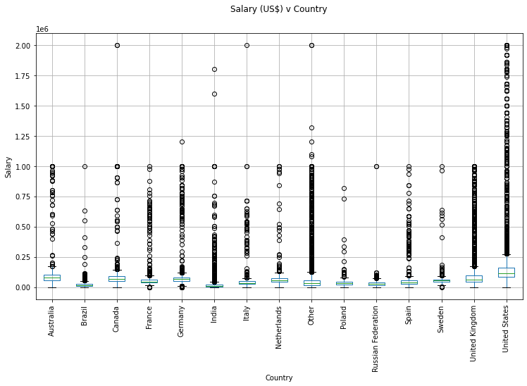

```python
fig, ax = plt.subplots(1,1, figsize=(12, 7))
df.boxplot('Salary', 'Country', ax=ax)
plt.suptitle('Salary (US$) v Country')
plt.title('')
plt.ylabel('Salary')
plt.xticks(rotation=90)
plt.show()
```

- EL gráfico que vemos encima corresponde a un diagrama de caja o boxplot, en el podemos ver lo diferentes paises en el eje x, y el salario en el eje y, con un rango que va desde 0 hasta 2 millones.

Este tipo de gráficos nos permite identificar valores atípicos y comparar distribuciones. Además de conocer de una forma cómoda y rápida como el 50% de los valores centrales se distribuyen. No es de extrañar que en un conjunto de datos se muestren máximos muy altos o mínimos muy bajos por lo que se considera que existen los valores raros.

En nuestro caso la interpretacion que nos daría el grafico de caja para nuestro conjunto de datos, son las cajas o areas pequeñas correponderian al valor medio y todos los puntos son en realidad valores atípicos, por lo que hay muchos valores atípicos en este dataframe, asi que la mayoria de los puntos de datos están en el área mediana, por lo que nos tocaría mantener solo los puntos de datos donde tenemos la mayor cantidad de información, lo haremos con el siguiente comando:

```python
df = df[df["Salary"] <= 250000]
df = df[df["Salary"] >= 10000]
df = df[df["Country"] != 'Other']
```

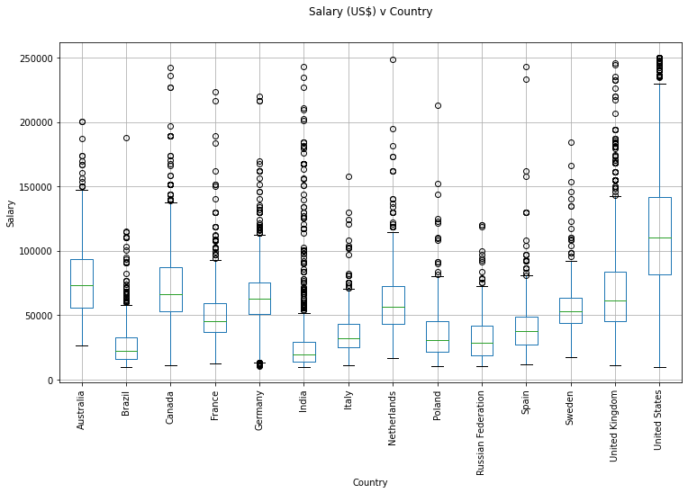

```python
fig, ax = plt.subplots(1,1, figsize=(12, 7))
df.boxplot('Salary', 'Country', ax=ax)
plt.suptitle('Salary (US$) v Country')
plt.title('')
plt.ylabel('Salary')
plt.xticks(rotation=90)
plt.show()
```

- Con el trazado nuevo de encima, podemos detectar mejores cajas y ver donde esta el rango medio, tambien podemos seguir detectando valores atípicos pero no tantos.
- Lo siguiente que haremos es limpiar la columna "YearsCodePro", antes haremos una inspeccion para ver el estado de los datos.

```python
df["YearsCodePro"].unique()
```

```
array(['13', '4', '2', '7', '20', '1', '3', '10', '12', '29', '6', '28',
       '8', '23', '15', '25', '9', '11', 'Less than 1 year', '5', '21',
       '16', '18', '14', '32', '19', '22', '38', '30', '26', '27', '17',
       '24', '34', '35', '33', '36', '40', '39', 'More than 50 years',
       '31', '37', '41', '45', '42', '44', '43', '50', '49'], dtype=object)
```

Vemos que tenemos valores de cadena, asi que lo siguiente a realizar es convertir estos valores de cadena a float, convirtiendo las cadenas **"Less than 1 year"** a **0.5** y **"More than 50 years"** a **50**.

Para hacer esto creamos una función `clean_experience` que obtiene x, y usamos una estructura condicional para el proposito describe lineas mas arriba.

```python
def clean_experience(x):
    if x ==  'More than 50 years':
        return 50
    if x == 'Less than 1 year':
        return 0.5
    return float(x)

df['YearsCodePro'] = df['YearsCodePro'].apply(clean_experience)
```

- Haremos lo mismo para la columna "EdLEvel" nivel de Educación.

```python
df["EdLevel"].unique()
```

```
array(['Bachelor’s degree (B.A., B.S., B.Eng., etc.)',
       'Master’s degree (M.A., M.S., M.Eng., MBA, etc.)',
       'Some college/university study without earning a degree',
       'Secondary school (e.g. American high school, German Realschule or Gymnasium, etc.)',
       'Associate degree (A.A., A.S., etc.)',
       'Professional degree (JD, MD, etc.)',
       'Other doctoral degree (Ph.D., Ed.D., etc.)',
       'I never completed any formal education',
       'Primary/elementary school'], dtype=object)
```

Si echamos un vistazo a todos estos valores unicos de la columna "EdLevel" vemos que tenemos muchas respuestas diferentes, por lo que aquí tambien queremos combinar algunas categorias, mantenemos la categoria "Bachelor's degree", "Master's degree", "Professional degree" o "Other Doctoral degree" y para todas las demás categorias decimos que es menor que Bachelor's.

Para hacer esto nuevamente creamos una función que nos ayude a combinar categorias y seleccionar lo que queramos la funcion se denominará `clean_education`

```python
def clean_education(x):
    if 'Bachelor’s degree' in x:
        return 'Bachelor’s degree'
    if 'Master’s degree' in x:
        return 'Master’s degree'
    if 'Professional degree' in x or 'Other doctoral' in x:
        return 'Post grad'
    return 'Less than a Bachelors'

df['EdLevel'] = df['EdLevel'].apply(clean_education)
```

- Ahora inspeccionamos los valores unicos nuevamente

```python
df["EdLevel"].unique()
```

```
array(['Bachelor’s degree', 'Master’s degree', 'Less than a Bachelors',
       'Post grad'], dtype=object)
```

- Como se puede observar la funcion ayudo a mantener los valores correctamente.
- Bien, ahora ya casi terminamos con la limpeza de los datos, pero todavia tenemos un problema y es que algunos de nuestros datos, como por ejemplo en la funcion `clean_experience` tenemos tipo de datos float. Y en la columna "EdLEvel" y "Country" tenemos datos de tipo cadena. Por lo que nuestro modelo no puede entender lo que es una cadena, asi que tenemos que transformar de tipo cadena en un valor unico, de modo que sea un numero que nuestro modelo pueda entender.

Por ejemplo para la salida de la funcion `clean_Education` en lugar de las cadenas **'Bachelo's degree', 'Master’s degree', 'Less than a Bachelors', 'Post grad'**, podriamos usar el numero 0,1,2,3 .

- Para realizar esta transformacion usamos la funcion `LabelEncoder` que importamos desde `sklearn.preprocessing`

```python
from sklearn.preprocessing import LabelEncoder
le_education = LabelEncoder()
df['EdLevel'] = le_education.fit_transform(df['EdLevel'])
df["EdLevel"].unique()
#le.classes_
```

```
array([0, 2, 1, 3])
```

Entonces podemos observar en el resultado de encima que ya no se tienen valores de cadena, en su lugar tenemos datos de valores numericos como 0,2,1,3, porlo que el orden no es realmente importante aqui , lo importante es que el codificador de etiquetas `le_education` sabe exactamente que numero pertenece a que cadena, pudiendo asi poder convertir esto denuevo.

Ahora ya que hicimos esto para la columna "EdLevel", entonces ahora hacemos lo mismo para la columna "Country" por lo que asignamos cada pais a un numero unico

```python
le_country = LabelEncoder()
df['Country'] = le_country.fit_transform(df['Country'])
df["Country"].unique()
```

```
array([13, 12, 10,  7,  4,  2,  6,  1,  3,  5, 11,  8,  0,  9])
```

Nuevamente el resultado nos muestra numeros en lugar de cadenas.

- Bien, ahora que ya tenemos el conjunto de datos limpio y normalizado podemos comenzar a entrenar nuestro modelo
> - ## Modeling data
- Como paso previo al entrenamiento del modelo, debemos dividir nuestros datos en las caracteristicas **X** y **y**, en la etiqueta X guardamos todas las caracteristicas de los puntos de datos para el modelo y en la etiqueta **y** guardamos la variable objetivo "Salary" que es lo que el modelo predecira

```python
X = df.drop("Salary", axis=1)
y = df["Salary"]
```

- A continuacion probaremos diferentes modelos de Machine Learning y para esto usamos la libreria **scikit-learn**, como primera aproximacion usamos la regresion lineal.

```python
from sklearn.linear_model import LinearRegression
linear_reg = LinearRegression()
linear_reg.fit(X, y.values)
```

```
LinearRegression()
```

Para predecir nuevos valores usamos la duncion `predict`

```python
y_pred = linear_reg.predict(X)
```

- Ahora para evaluar que tan bien se desempeña nuestro modelo para el problema de grafica de regresion, generalmente usamos herramientas como el error cuadratico medio o tambien el error absoluto promedio, porlo que importamos estas herramientas:

```python
from sklearn.metrics import mean_squared_error, mean_absolute_error
import numpy as np
error = np.sqrt(mean_squared_error(y, y_pred))
error
```

```
39274.75368318509
```

```python
from sklearn.tree import DecisionTreeRegressor
dec_tree_reg = DecisionTreeRegressor(random_state=0)
dec_tree_reg.fit(X, y.values)
```

```
DecisionTreeRegressor(random_state=0)
```

```python
y_pred = dec_tree_reg.predict(X)
```

```python
error = np.sqrt(mean_squared_error(y, y_pred))
print("${:,.02f}".format(error))
```

```
$29,414.94
```

Verificando el resultado, esta vez la rai cuadrada del error cuadratico medio es solo 29000, porlo que esto esta mucho mejor.

- Pero probaremos tambien con otro modelo que es el Random Forest Regressor (Regresor de bosque aleatorio), este modelo basicamente combina multiples arboles de decision en un bosque, asi que usamos el mismo enfoque para este modelo.

```python
from sklearn.ensemble import RandomForestRegressor
random_forest_reg = RandomForestRegressor(random_state=0)
random_forest_reg.fit(X, y.values)
```

```
RandomForestRegressor(random_state=0)
```

```python
y_pred = random_forest_reg.predict(X)
```

```python
error = np.sqrt(mean_squared_error(y, y_pred))
print("${:,.02f}".format(error))
```

```
$29,487.31
```

Echamos un vistazo al resultado y esta vez y el error sigue siendo 29000, porlo que no es realmente mejor que el Arbol de Decisiones.

- Entonces seguir probando mas modelos sería un poco engorroso, por lo que ahora consideraremos realizar, es que para cada uno de los modelos ya usados, probaremos a usar diferentes valores de parametros, por ejemplo para El Arbol de Decisiones podemos usar un parametro de profundidad maxima y luego podria funcionar de manera muy diferente para diferentes parametros.
- Por lo que ahora para encontrar el mejor modelo con los mejores parametros existe un metodo llamado `GridSearchCV` que significa Busqueda de Cuadricula con Validacion Cruzada.
- La forma en que funciona el metodo es importando GRidSearchCV, y luego definimos el conjunto de diferentes parametros que queremos probar y lo almacenamos en `max_depth` y luego creamos un diccionario de parametros.

```python
from sklearn.model_selection import GridSearchCV

max_depth = [None, 2,4,6,8,10,12]
parameters = {"max_depth": max_depth}

regressor = DecisionTreeRegressor(random_state=0)
gs = GridSearchCV(regressor, parameters, scoring='neg_mean_squared_error')
gs.fit(X, y.values)
```

```
GridSearchCV(estimator=DecisionTreeRegressor(random_state=0),
             param_grid={'max_depth': [None, 2, 4, 6, 8, 10, 12]},
             scoring='neg_mean_squared_error')
```

Al ejecutar el comando de arriba lo que sucede es basicamente recorrer todos los diferentes parametros que se colocaron en **max_depth** y probará todos los diferentes parametros y cada vez evalua el error y luego elije el mejor modelo para los datos.

- Ahora obtenemos el mejor estimador

```python
regressor = gs.best_estimator_

regressor.fit(X, y.values)
y_pred = regressor.predict(X)
error = np.sqrt(mean_squared_error(y, y_pred))
print("${:,.02f}".format(error))
```

```
$30,428.51
```

Asi que este es el error final que obtenemos para nuestro regresor final, y ahora aplicamos modelo a los nuevos datos, pero antes echemos un vistazo de nuevo al dataframe

```python
X
```

|  | Country | EdLevel | YearsCodePro |
| --- | --- | --- | --- |
| 7 | 13 | 0 | 13.0 |
| 9 | 12 | 2 | 4.0 |
| 10 | 12 | 0 | 2.0 |
| 11 | 10 | 1 | 7.0 |
| 12 | 7 | 1 | 20.0 |
| ... | ... | ... | ... |
| 64113 | 13 | 1 | 15.0 |
| 64116 | 13 | 0 | 6.0 |
| 64122 | 13 | 1 | 4.0 |
| 64127 | 13 | 3 | 12.0 |
| 64129 | 13 | 2 | 4.0 |

18491 rows × 3 columns

- Asi que suponiendo en la nueva aplicacion mas adelante, obtenemos una nueva matriz con el siguiente codigo

```python
# country, edlevel, yearscode
X = np.array([["United States", 'Master’s degree', 15 ]])
X
```

```
array([['United States', 'Master’s degree', '15']], dtype='<U15')
```

- Suponiendo que el usuario en la nueva aplicacion pone como el pais y nivel de educacion y los años de experiencia, entonces en nuestra X veriamos algo como el resultado de arriba.

Lo que queremos hacer con esta prueba es aplicar el codificador de etiquetas para "Country" porlo que seria la columna cero, luego queremos aplicar el codificador de etiquetas para "EdLEvel"

```python
X[:, 0] = le_country.transform(X[:,0])
X[:, 1] = le_education.transform(X[:,1])
X = X.astype(float)
X
```

```
array([[13.,  2., 15.]])
```

- Asi que una vez aplicado los codificadores de etiquetas obtenemos los valores numericos y podemos poner esto en nuestro regresor y luego predecir.

```python
y_pred = regressor.predict(X)
y_pred
```

```
array([139427.26315789])
```

Por lo que con esa informacion ya podemos ver el salario que predijo el modelo, y ahora es lo que tenemos que hacer en nuestra App.

**!!!A PARTIR DE ESTE PUNTO SI EL CODIGO ES CORRECTO NO VOLVER A GUARDAR CON PICKLE PORQUE CUALQUIER CAMBIO EN saved_steps.pkl AFECTARIA A LA APP WEB QUE ESTA COMPILADA EN VISUAL CODE !!!**

> - ## Guardando el Modelo
- **Pero antes de que podamos usar estos datos en nuestra App web, primero tenemos que por supuesto guardar nuestro modelo, y para esto usamos *pickle*, asi que ahora importamos pickle**

```python
import pickle
```

- Y luego le decimos que guarde el `regressor`, el codificador de etiquetas `le_country` y el codificador de etiquetas `le_education`.
- Para hacer esta tarea creamos un diccionario que guardamos en `data`
- Luego con `with open('saved_steps.pkl', 'wb') as file` abrimos un archivo de pickle y aqui con `'wb'`queremos abrir esto en el modo binario correcto esto es importante para pickle.
- Y luego con `pickle.dump(data, file)` le decimos a pickle volcar `data` en `file`.
- Ahora al ejecutar la siguiente linea de comando, deberia guardar `data` en nuestro directorio

```python
data = {"model": regressor, "le_country": le_country, "le_education": le_education}
with open('saved_steps.pkl', 'wb') as file:
    pickle.dump(data, file)
```

- Podemos revisar lo que guardamos, cargando de nuevo en modo binario de lectura a eso se refiere la variable `'rb'` read binary o leer binario y decimos `data = pickle.load(file)`.

```python
with open('saved_steps.pkl', 'rb') as file:
    data = pickle.load(file)
```

- Ahora podemos acceder al modelo, el codificador de etiquetas para country y EdLevel accediendo a la clave, asi que recuperemoslo de `data` y luego ejecutaremos la prediccion con nuestro modelo cargado nuevamente y luego vemos que obtenemos exactamente el mismo numero que obtuvimos mas arriba del modelo original. Veamoslo

```python
regressor_loaded = data["model"]
le_country = data["le_country"]
le_education = data["le_education"]
```

```python
y_pred = regressor_loaded.predict(X)
y_pred
```

```
array([139427.26315789])
```

- Por lo que guardar y cargar funciona bien. Asi que ahora ya concluimos con el analisis, limpieza, modelado , guardado del modelo y cargado y prueba del modelo. Entonces tenemos la canalizacion completa aqui. Lo que resta es Convertir parte de este codigo de este cuaderno en nuestra APP Web.